# Analysis on Prosper loan data

Ka Hung Wong

Oct 21, 2017

# Introduction

The loan data described in this notebook is obtained from [Prosper](https://www.prosper.com/), which is the first peer-to-peer lending marketplace in US. The data contains 113937 lending cases with 81 variables from 2005 to 2014.

As a peer-to-peer lending marketplace, it is important to predict the health of a loan, *i.e.*, how likely to collect the debt, based on the information form the borrowers. In this notebook, we will apply exploring data analysis for this purpose.

# Load the library

The libraries that will be used in the notebook are loaded. They are: 1. *dplyr*, 2. *tidyr*, 3. *ggplot2*, and 4. *lubridate*.

# Load data

The data is stored in a CSV file, *prosperLoanData.csv*, and we import the data via function *read.csv*. Although there are 81 variables, we will explore the variables that is highly related with the financial health of the borrowers: *CreditGrade*, *ProsperRating*, *Term*, *LoanStatus*, *BorrowerAPR*, *BorrowerRate*, *EmploymentStatus*, *EmploymentStatusDuration*, *IsBorrowerHomeowner*, *CreditScoreRangeLower*, *CreditScoreRangeUpper*, *CurrentDelinquencies*, *DelinquenciesLast7Years*, *BankcardUtilization*, *DebtToIncomeRatio*, *IncomeRange*.

```
## 'data.frame':    113937 obs. of  81 variables:
##  $ ListingKey                         : Factor w/ 113066 levels "00003546482094282EF90E5",..: 7180 7193 6647 6669 6686 6689 6699 6706 6687 6687 ...
##  $ ListingNumber                      : int  193129 1209647 81716 658116 909464 1074836 750899 768193 1023355 1023355 ...
##  $ ListingCreationDate                : Factor w/ 113064 levels "2005-11-09 20:44:28.847000000",..: 14184 111894 6429 64760 85967 100310 72556 74019 97834 97834 ...
##  $ CreditGrade                        : Factor w/ 9 levels "","A","AA","B",..: 5 1 8 1 1 1 1 1 1 1 ...
##  $ Term                               : int  36 36 36 36 36 60 36 36 36 36 ...
##  $ LoanStatus                         : Factor w/ 12 levels "Cancelled","Chargedoff",..: 3 4 3 4 4 4 4 4 4 4 ...
##  $ ClosedDate                         : Factor w/ 2803 levels "","2005-11-25 00:00:00",..: 1138 1 1263 1 1 1 1 1 1 1 ...
##  $ BorrowerAPR                        : num  0.165 0.12 0.283 0.125 0.246 ...
##  $ BorrowerRate                       : num  0.158 0.092 0.275 0.0974 0.2085 ...
##  $ LenderYield                        : num  0.138 0.082 0.24 0.0874 0.1985 ...
##  $ EstimatedEffectiveYield            : num  NA 0.0796 NA 0.0849 0.1832 ...
##  $ EstimatedLoss                      : num  NA 0.0249 NA 0.0249 0.0925 ...
##  $ EstimatedReturn                    : num  NA 0.0547 NA 0.06 0.0907 ...
##  $ ProsperRating..numeric.            : int  NA 6 NA 6 3 5 2 4 7 7 ...
```

[output cut: 67 more lines]

# Univariate Plots Section

## LoanStatus

Most of the loan cases are in the current status, followed by the completed cases. However, there is quite amount of charged-off and defaulted loans. Some of the loans are in the final payment progress and past-due with different length of times, and cancelled.

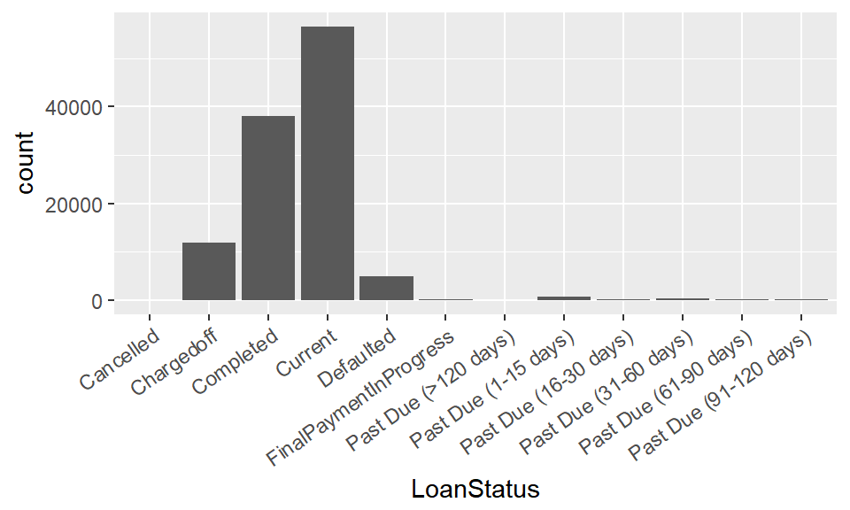

The aim of this notebook is to explore the health of loans based on Prosper data. It is convenient to separate the loan status into two levels: *good* and *bad* such that the health status is reduced to binary problem. Here, charged-off, defaulted, cancelled, and past-due status are combined and are labeled as *bad*. All the rest of the status except current status are considered as *good* status. Current status means the loan is normal at the time when the dataset is created, but this does not guarantee a good loan since the loan have not finished. So we focus on the *good* and *bad* cases. There are about 2X more loan cases are in *good* status based on the bar chart below, and thus the distribution of loan status is imbalance.

Since we will ignore the current status, therefore a subset of labelled loan cases, in which only good and bad loans are considered, is created for further analysis.

```
##
##     bad Current    good
##   19082   56576   38279
```

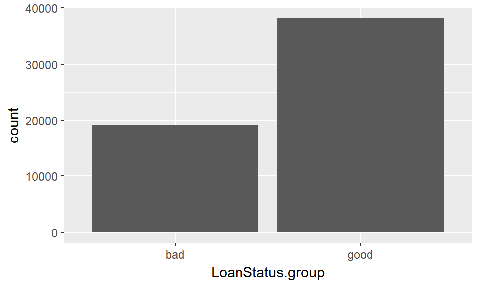

## ListingCreationDate

*ListingCreationDate* is not directly related with the borrowers’ financial health, it however relates with the credit grading systems used in the Prosper. This variables records the date that the loan was created. We can see that there is a discontinuity on the histogram, and this is probably related with the fact that Prosper had suspended and relaunched her lending business around July 2009.

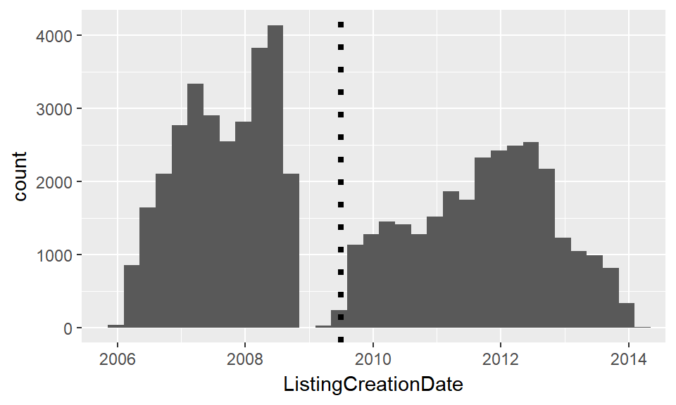

## CreditGrade and ProsperRating

Two variables related with credit scores defined by Prosper are considered: *CreditGrade* and *ProsperRating..numeric.*. *CreditGrade* is the credit score before the relaunch of the business, while *ProsperRating..numeric.* is score used after the relaunch of the business. Since both of them refers to the same property, we first transform the credit grade to numeric by the following rules: 0 - N/A, 1 - HR, 2 - E, 3 - D, 4 - C, 5 - B, 6 - A, 7 - AA. Then, we create a new variable by combining both of them to get a credit score covering the entire time interval.

A bar chat of *CreditGrade.combined* is plotted, and the distribution of the combined credit grade is quite normal. We have more loan cases within interval of (3,5).

```
##
##     1     2     3     4     5     6     7
##  7543  7526 11507  9993  8079  7111  5330
```

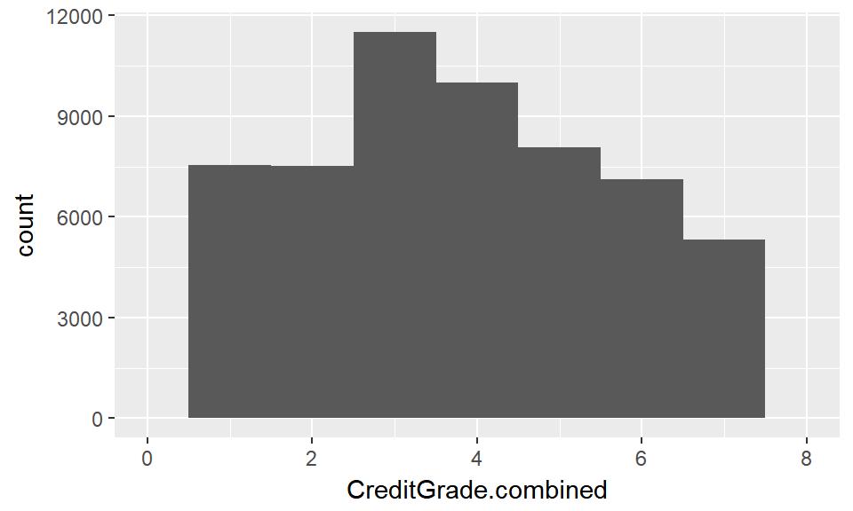

## Term

```
##
##    12    36    60
##  1552 51391  4418
```

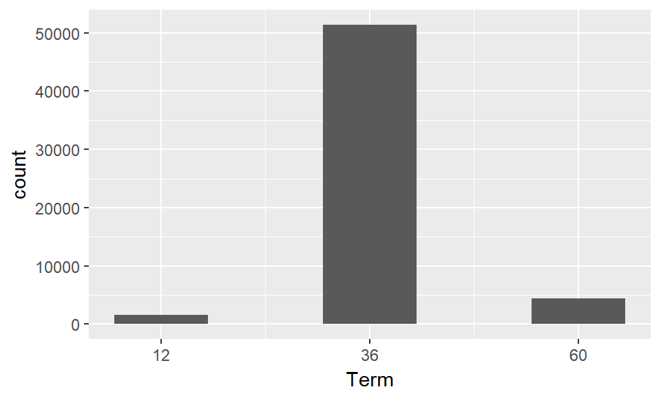

## BorrowerAPR and BorrowerRate

A simple histogram of *BorrowerAPR* is created. Most of the loan APRs are from 0.15 (Q1) to 0.30 (Q3). The mean and median APRs are 0.22.

```
##    Min. 1st Qu.  Median    Mean 3rd Qu.    Max.    NA's
## 0.00653 0.15211 0.21739 0.22385 0.29554 0.51229      25
```

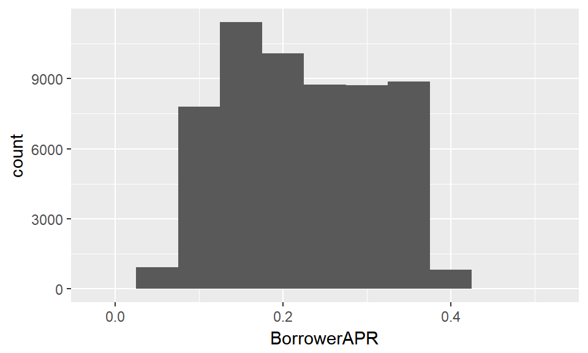

The borrower’s interest rates is highly related with the APR of the loan with correlation of 0.99 since the interest rate can be calculated from the APR with the given term. Therefore, we can use one of them to represent the interest rate of the loan.

```
##    Min. 1st Qu.  Median    Mean 3rd Qu.    Max.
##  0.0000  0.1364  0.1980  0.2016  0.2699  0.4975
```

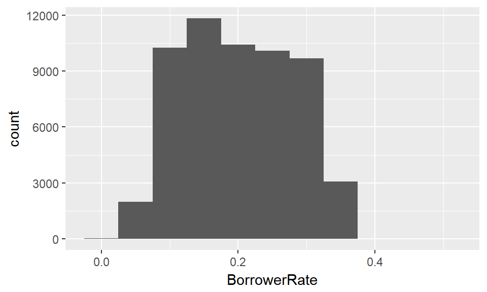

```
##
##  Pearson's product-moment correlation
##
## data:  loan_labelled$BorrowerAPR and loan_labelled$BorrowerRate
## t = 1565.2, df = 57334, p-value < 2.2e-16
## alternative hypothesis: true correlation is not equal to 0
## 95 percent confidence interval:
##  0.9883114 0.9886857
## sample estimates:
##       cor
## 0.9885001
```

## EmploymentStatus and EmploymentStatusDuration

Most of the borrowers are employed or have a full-time job.

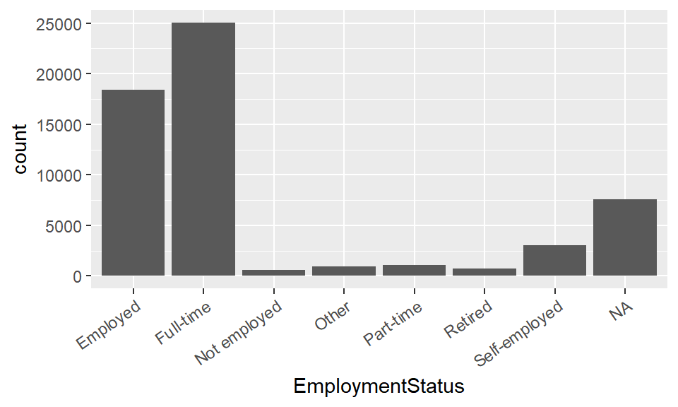

The length in months of the employment status at the time the listing was created and named as *EmploymentStatusDuration*. Most of the borrowers have the duration between 0 to 100 months, this may indicates the age of the borrowers since older people have a higher chance to gain more work experience.

```
##    Min. 1st Qu.  Median    Mean 3rd Qu.    Max.    NA's
##    0.00   21.00   53.00   81.62  113.00  755.00    7615
```

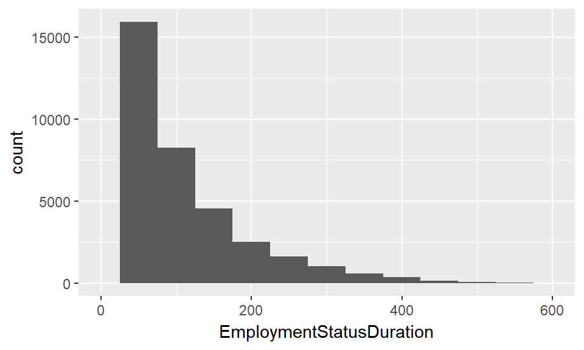

## IsBorrowerHomeowner

The home-ownership may be an important factor to determine the health of the loan. The bar chart suggests half of the borrowers own a house.

```
## False  True
## 30361 27000
```

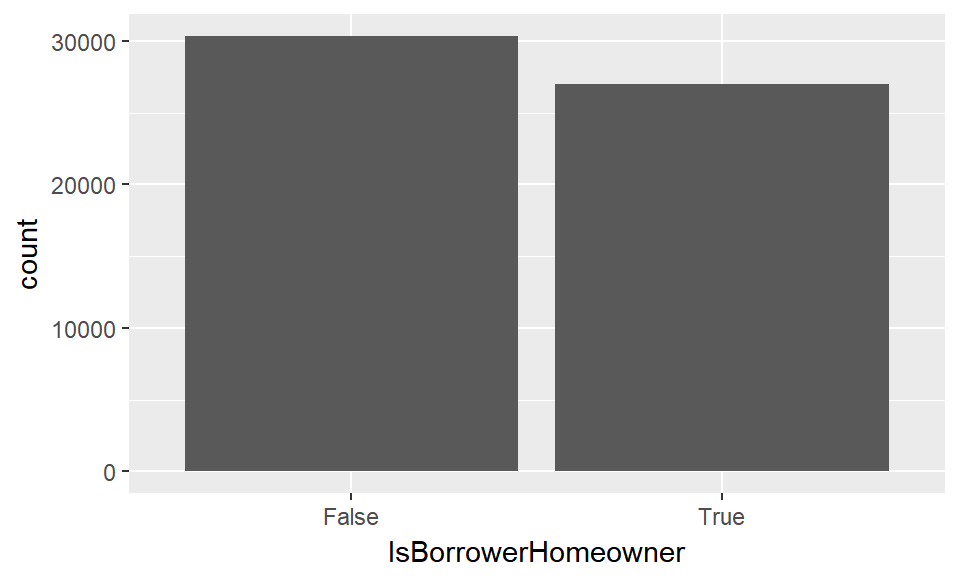

## CreditScoreRangeLower and CreditScoreRangeUpper

Credit scores from other agents are also recorded, and the lower and upper values are marked. Based on the histograms, the distribution between the lower and upper scores are very similar with correlation of 1. Some borrowers have a extreme low credit scores like zero. This probably represents the data that is not available.

```
##    Min. 1st Qu.  Median    Mean 3rd Qu.    Max.    NA's
##     0.0   640.0   680.0   672.4   720.0   880.0     591
```

```
##    Min. 1st Qu.  Median    Mean 3rd Qu.    Max.    NA's
##    19.0   659.0   699.0   691.4   739.0   899.0     591
```

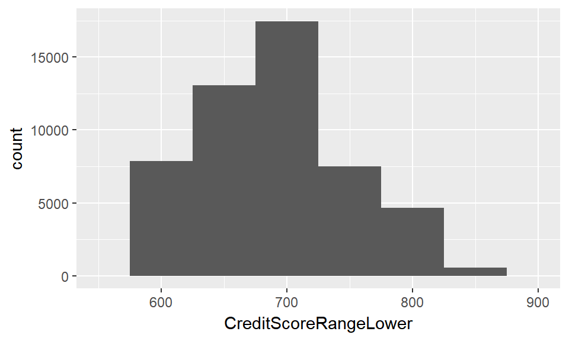

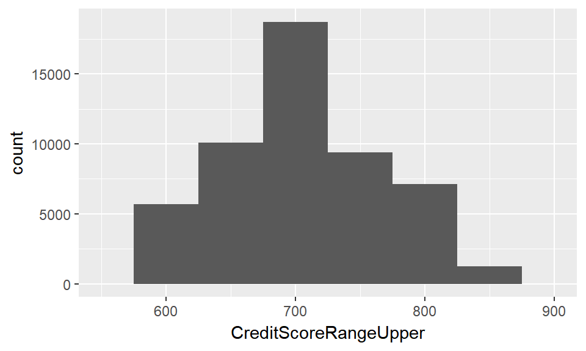

```
##
##  Pearson's product-moment correlation
##
## data:  CreditScoreRangeLower and CreditScoreRangeUpper
## t = Inf, df = 56768, p-value < 2.2e-16
## alternative hypothesis: true correlation is not equal to 0
## 95 percent confidence interval:
##  1 1
## sample estimates:
## cor
##   1
```

## CurrentDelinquencies and DelinquenciesLast7Years

```
##    Min. 1st Qu.  Median    Mean 3rd Qu.    Max.    NA's
##   0.000   0.000   0.000   4.579   4.000  99.000     990
```

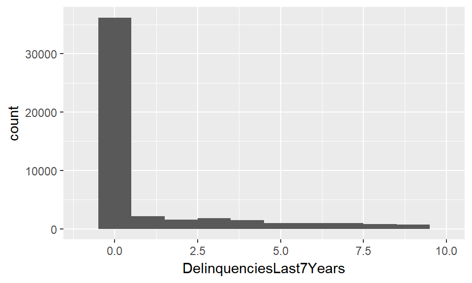

```
##    Min. 1st Qu.  Median    Mean 3rd Qu.    Max.    NA's
##   0.000   0.000   0.000   0.891   1.000  83.000     697
```

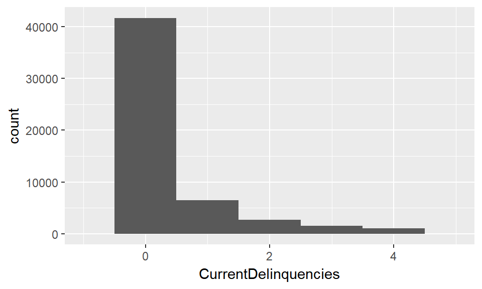

```
##
##  Pearson's product-moment correlation
##
## data:  CurrentDelinquencies and DelinquenciesLast7Years
## t = 132.61, df = 56369, p-value < 2.2e-16
## alternative hypothesis: true correlation is not equal to 0
## 95 percent confidence interval:
##  0.4813277 0.4939120
## sample estimates:
##       cor
## 0.4876451
```

## BankcardUtilization

The bank card utilization is the percentage of available revolving credit that is utilized at the time the credit profile was pulled. Most of the borrowers has the utilization between 0 to 1. However, some of them are the heavy users, and we cap this value at 1.51.

```
##    Min. 1st Qu.  Median    Mean 3rd Qu.    Max.    NA's
##   0.000   0.220   0.570   0.532   0.850   5.950    7604
```

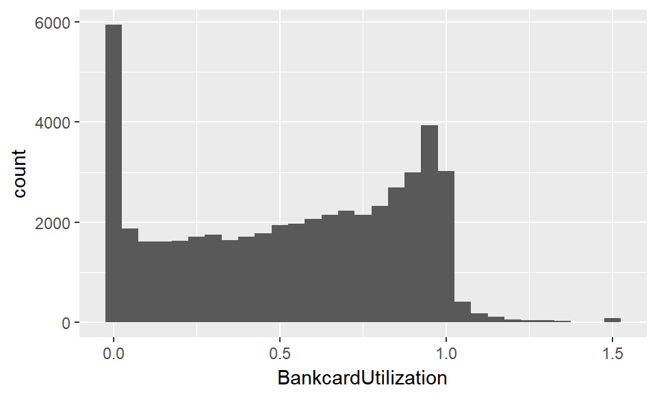

## DebtToIncomeRatio

This is the debt to income ratio of the borrower at the time the credit profile was pulled. This value is Null if the debt to income ratio is not available. This value is capped at 10.01 (any debt to income ratio larger than 1000% will be returned as 1001%). Most of the borrowers have the ratios between 0 to 1, but some of them are having big debt. The variable may give some information about the purpose of the loans.

```
##    Min. 1st Qu.  Median    Mean 3rd Qu.    Max.    NA's
##    0.00    0.13    0.20    0.29    0.30   10.01    4456
```

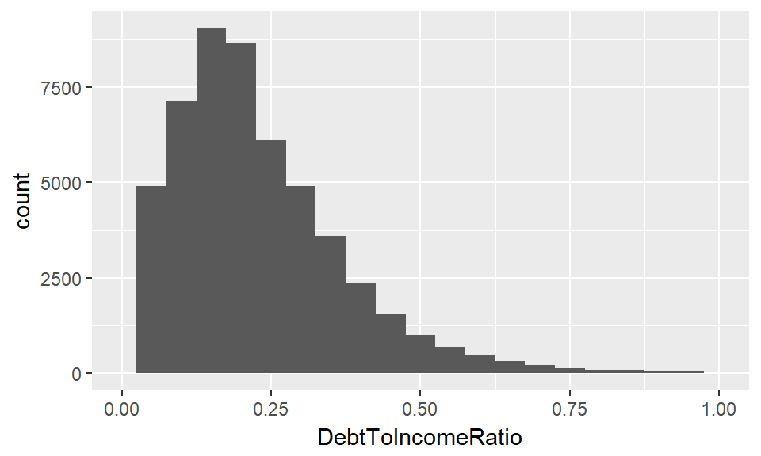

## IncomeRange and IncomeVerifiable

```
##
##             $0      $1-24,999      $100,000+ $25,000-49,999 $50,000-74,999
##            610           4738           6421          17081          13435
## $75,000-99,999  Not displayed   Not employed
##           6777           7741            558
```

```
##             $0      $1-24,999 $25,000-49,999 $50,000-74,999 $75,000-99,999
##            610           4738          17081          13435           6777
##      $100,000+   Not employed           NA's
##           6421            558           7741
```

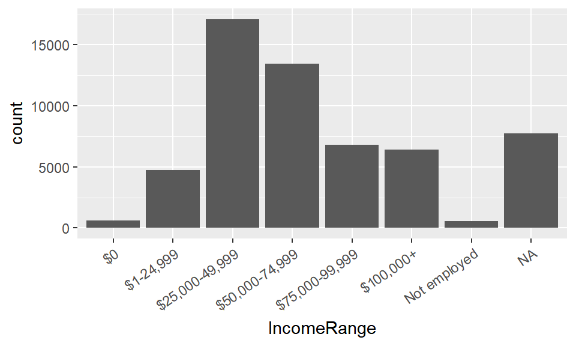

The income levels can be validated with the supporting documents, but not all borrowers (~4500) can provide documentation to support their incomes.

```
## False  True
##  4527 52834
```

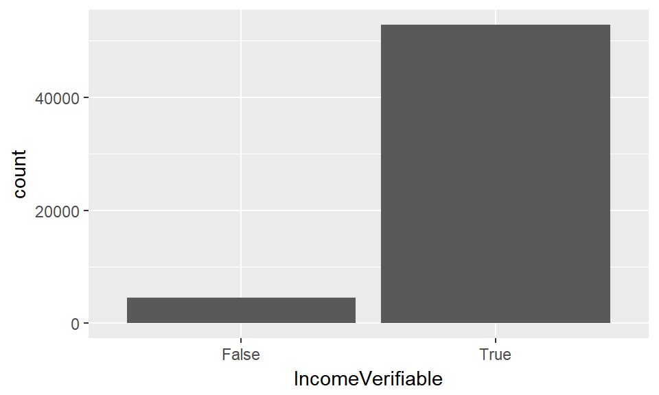

# Univariate Analysis

The dataset is in the wide format but it is still quite tidy. Although there is small missing data in the dataset, the missing rate is not very high. Some transformation may be required on some variables for further analysis.

The main feature of interest is the grouped loan status (*LoanStatus.group*), which is transformed variable based on *LoanStatus*. The variable contains the health of the loans at the time when the dataset was created.

The variables we considered in the last section could have impacts on the grouped loan status. The credit scores from Prosper or other agents are the main variables that indicates the financial health of the borrowers. However, the rest of the variables are also linked to borrowers’ characteristics, which may provide various degrees of information related with the loan status.

We also create a new variable, *CreditGrade.combined*, which is the combined credit grade based on *CreditGrade* and *ProsperRating..Alpha.* representing the credit grading systems before and after Prosper’s business relaunch. This variable can capture the credit grade assigned by Prosper for the entire time interval of the dataset.

In general, the continuous variables are easily to handle since no factor is not involved. However, more cautions are required to handle the discrete variables to obtain proper order, factor, and NA representation.

# Bivariate Plots Section

## Credit Grades

Credit scores are created in Prosper or other agents, which are represented by the *CreditGrade.combined* and *CreditScoreRangeLower*. The Propser credit score has 7 ratings from ‘AA’ to ‘HR’ (high risk). From the bar chart below, we can see that better credit score has a better chance to have a health loan. There is some borrowers have no Prosper credit score, which is one type of missing values. However, the missing data is not missing at random. The probability to have a bad loan status given the Prosper credit score is missing is higher than the average. This suggests we may extract information relates to loan status even the loan status is missing.

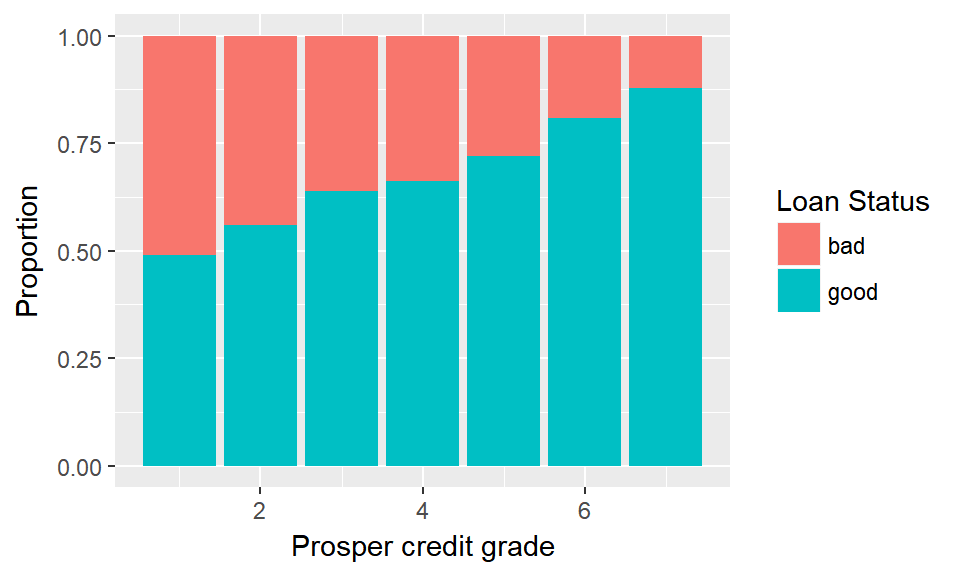

Most of the credit scores from other agents are larger than 250. Some of them are zero, which may indicate no credit scores was obtained when the loan was created in these cases. For the rest of the data, we can see a similar trend with the Prosper credit grade, in which the higher credit score the lower the chance to have a bad loan.

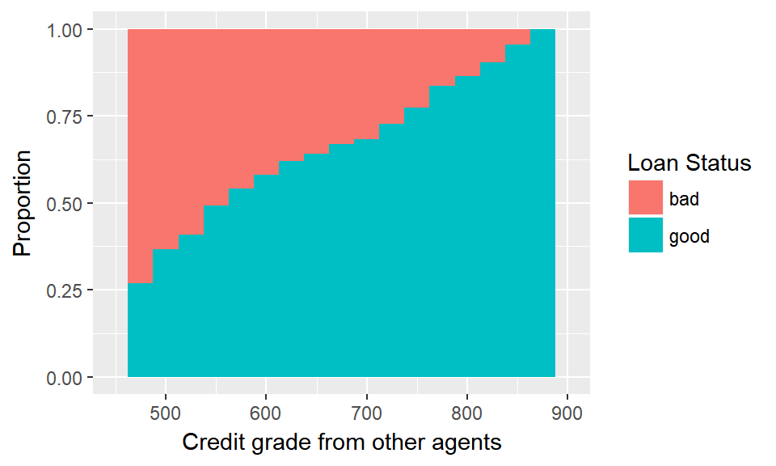

## Other supporting variables

### Term

It is surprised that there is more bad loans with 60-month term (pay less per month).

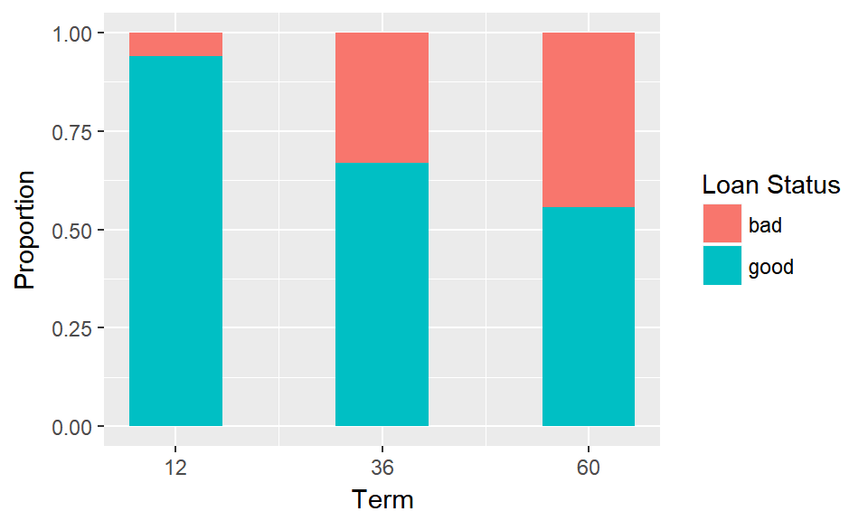

### BorrowerAPR

The rate of the loan seems to have some correlation with loan status. When the loan rate is low (between 0.05 to 0.2), there is a higher proportion of good loan. When the rate of loan is increased, the chance to have a bad loan is also increased. This is quite reasonable since it is more difficult to make the payment if the interest rate is high.

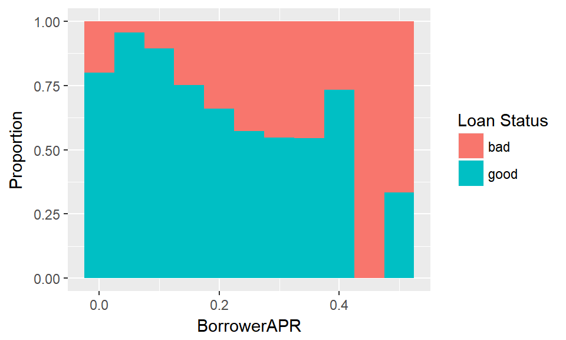

### EmploymentStatus

The borrowers who have a stable job (even for part-time), there is a higher chance for them to finished the payment. The rest of the borrowers seems to have more difficult to complete their payments.

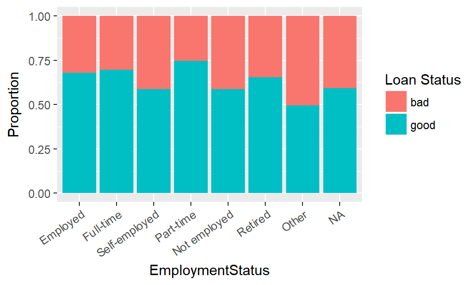

### EmploymentStatusDuration

The data suggests there is not much different in the ratio of bad and good loan when the employment status duration is between 0 to 500 months.

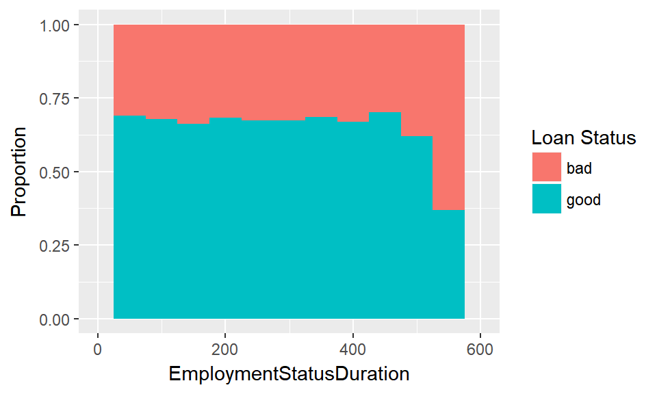

### isBorrowerHomeowner

At the beginning, I assumed that the financial health is better for the borrowers who have a home. However, the assumption is not valid base on the plot we have. Therefore, we will skip this variable in the next analysis.

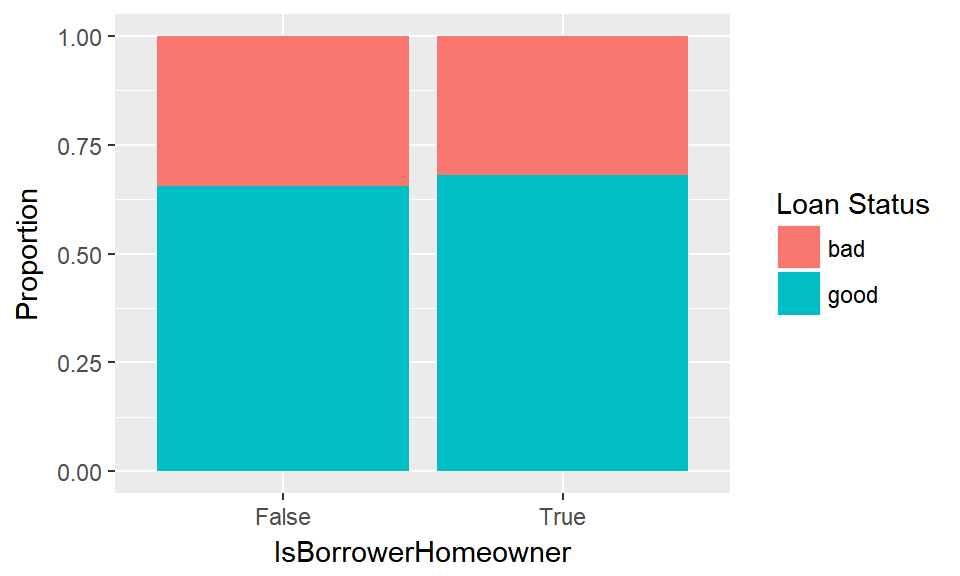

### DelinquenciesLast7Years

The plot suggests the borrowers who have a bad delinquent history trends to not paying the loan, but the trend is not that obvious.

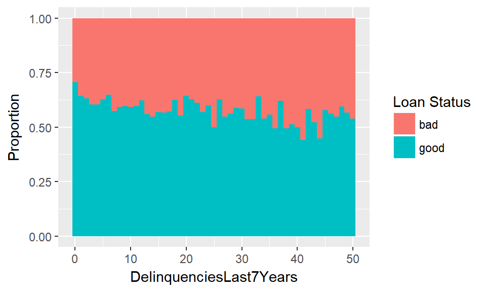

### CurrentDelinquencies

The more in the delinquent account, the higher chance to have a bad loan.

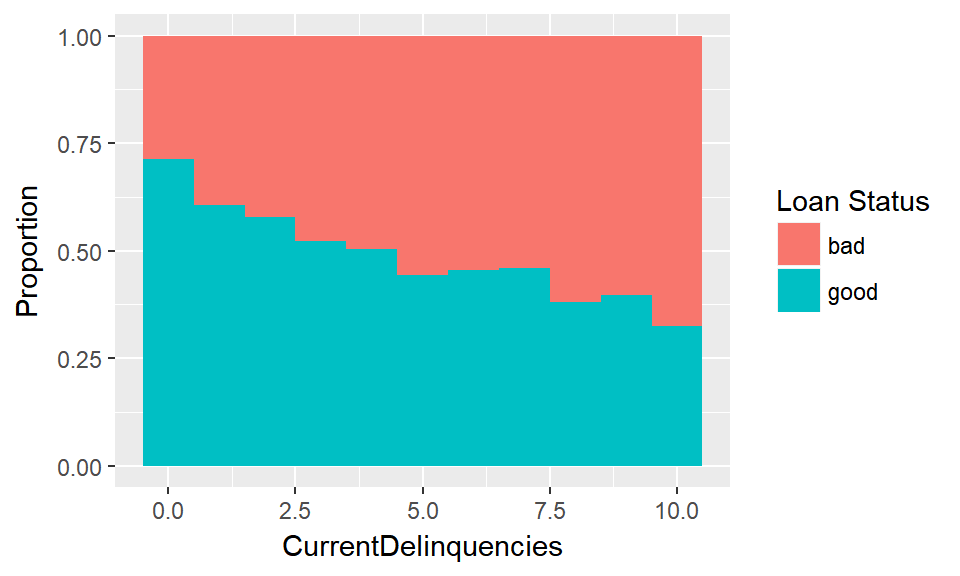

### BankcardUtilization

When the utilization is less than 1, there is a good chance to have a good loan.

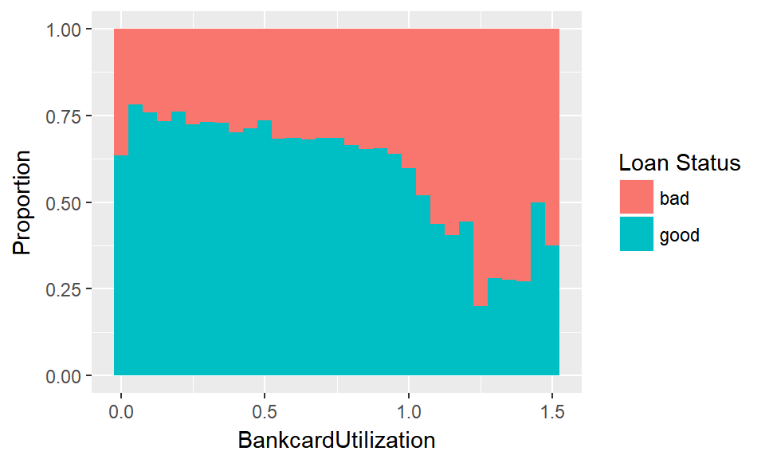

### DebtToIncomeRatio

The higher the debt to income ratio, the higher chance to get a bad loan. It is quite reasonable since the more debt the more difficult to pay the loan.

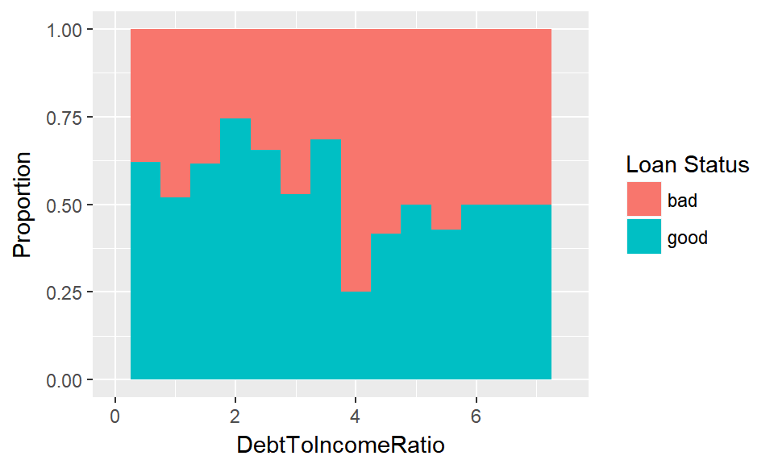

### IncomeRange

The data suggest the higher the higher in income the higher chance in getting a good loan. The missing data is not random since there is higher chance to have a bad loan provided the data is missing.

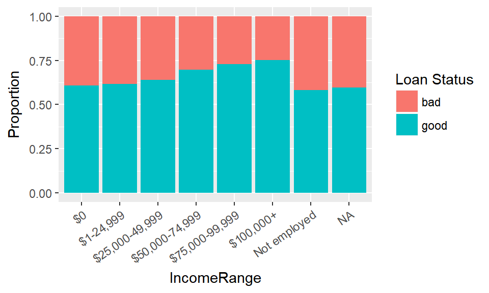

### IncomeVerifiable

The present of the valid document to support the income seems not a strong evidence to indicate the status of the loan according to the small difference between the case with or without the valid documents. Therefore, we ignore this variable in the next analysis.

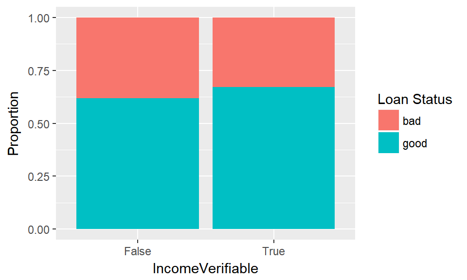

# Bivariate Analysis

The main features, *i.e.,* the credit grades from Prosper and other agents, show strong relationship with the loan status. However, other features such as the interest rate, the current delinquencies, etc are also have a relationship with the loan status.

In the main features, the credit grade obtained from other agents seems to have the strongest relationship to the loan status. For the supporting features, the interest rate also shows a strong relationship with the loan status.

# Multivariate Plots Section

We create a subset of labelled data by considering the following 12 variables: “Term”, “BorrowerAPR”, “EmploymentStatus”, “EmploymentStatusDuration”, “CurrentDelinquencies”, “DelinquenciesLast7Years”, “BankcardUtilization”, “DebtToIncomeRatio”, “IncomeRange”, “CreditScoreRangeLower”, “CreditGrade.combined”, and “LoanStatus.group”. Then we rename the variables as “term”, “APR”, “emp_stat”, “emp_stat_dur”, “cur_delq”, “past_delq”, “card_usage”, “deb_income”, “income_rng”, “credit_score”, “credit_grade”, and “loan_stat” for better visualization in the plots.

## Missing data

We provide some analysis on the subset of the loan data that are related with the missing data.

The left plot is a bar chart with the proportion of missing values in each variable. In the resulted graphic suggests that the income range, employment status and its duration, and card utilization are having the highest amount of missed values (about ~13%). The debt to income ratio also has a high missing rate (~8%). While the rest of the variables have a much smaller missing rate (<2%).

The right is an aggregation plot of missing information, which shows the existing combinations of missing values. This combination plot reveals that if the observations are missing in one of the variables of income range, employment status and its duration, and card utilization, they are probably missing in other variables in this group. This suggests the missing data is not totally random.

Since the missing data is correlated, therefore about ~13% of the data is removed if all missing data is deleted. A completed dataset is generated by removing all the missing values.

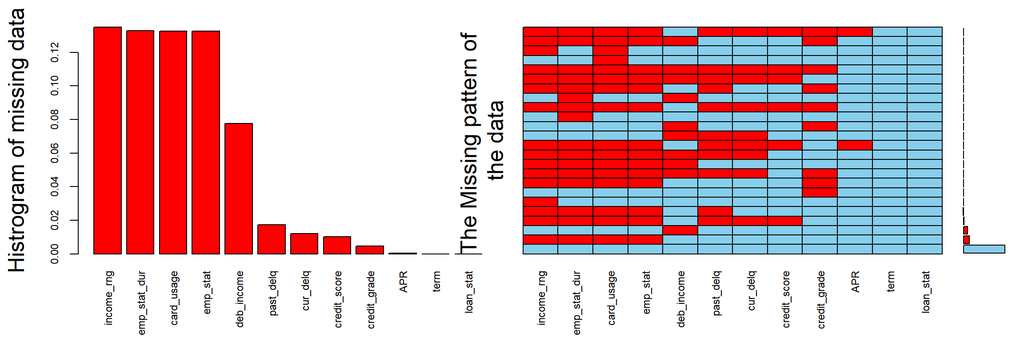

```
##
##  Variables sorted by number of missings:
##      Variable        Count
##    income_rng 0.1349523195
##  emp_stat_dur 0.1327557051
##    card_usage 0.1325639372
##      emp_stat 0.1325290703
##    deb_income 0.0776834435
##     past_delq 0.0172591133
##      cur_delq 0.0121511131
##  credit_score 0.0103031677
##  credit_grade 0.0047418978
##           APR 0.0004358362
##          term 0.0000000000
##     loan_stat 0.0000000000
```

## Scatterplot Matrix

We plot a scatter-plot matrix for the continuous variables (“APR”, “emp_stat_dur”, “cur_delq”, “past_delq”, “card_usage”, “deb_income”, “credit_score”, “credit_grade”) as an overview.

We notice that the interest rate of the loan has a positive correlation with the current and past delinquencies, the card utilization, and has a negative correlation with the credit score and grade, which suggests these variables are considered in determining the interest rate in Prosper.

The credit score and grade has correlation with the delinquent history and card utilization, which suggests the delinquent history and card utilization are important for determining the credit score and grade.

It is surprised that the employment status duration and the debt to income ratio do not have any significant correlations with the interest rate, the delinquent history, card utilization, and the credit score.

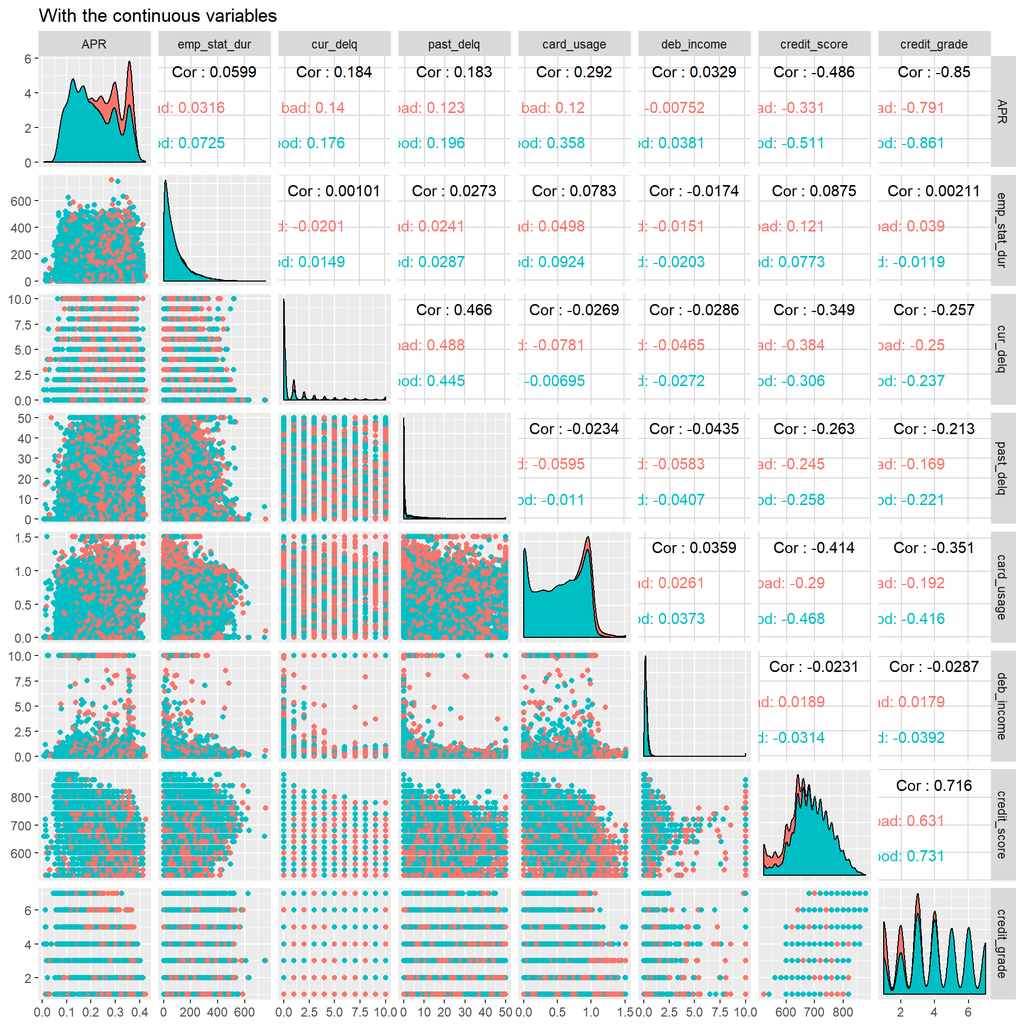

## Prosper vs Non-Prosper Credit Scores

There are two credit scores in the variables of interest, they are ‘credit_grade’ and ‘credit_score’ calculated from Prosper and other agents, respectively. We can see that there is a correlation between the Prosper and non-Prosper credit scores, which suggests Prosper and other agents may share some mutual information about the borrowers.

In the plot, the points are jittered in order to have a better visualization. We can see that there is more bad loan concentrated at the left and bottom corner of the plot, which suggests there is a higher chance to get bad loan when the Prosper and non-Prosper credit scores of the borrowers are poor.

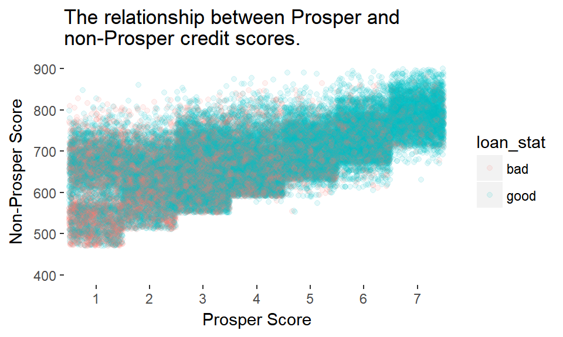

## Interest Rate vs Prosper Credit Score

In the plot, the points are jittered in order to have a better visualization. We can see that there is more bad loan concentrated at the left and upper corner of the plot, which suggests there is a higher chance to get bad loan when the Prosper credit score is low and the interest rate is high.

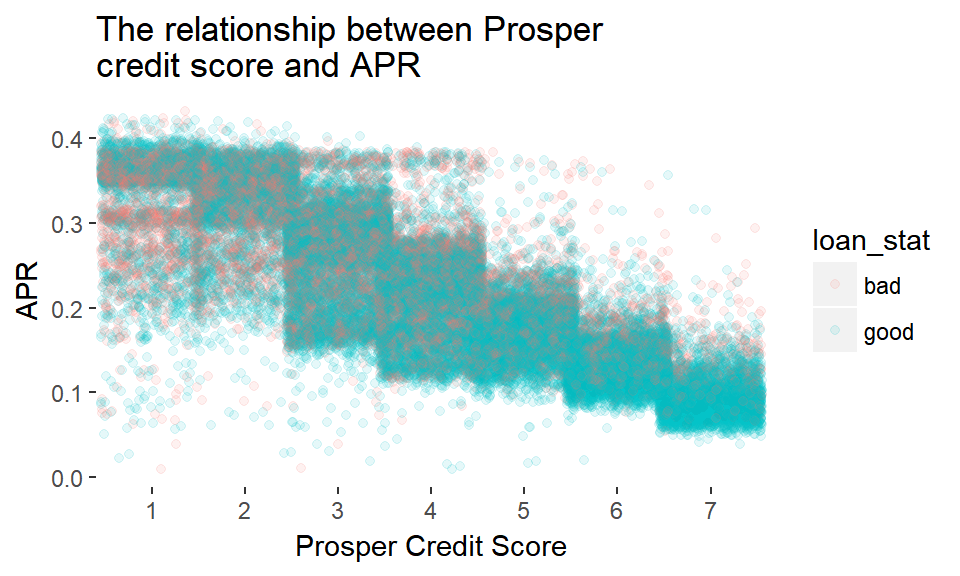

# Multivariate Analysis

## Machine learning

Finally, we develop a decision tree classifier to predict the status of loan based on a labelled subset of the loan dataset. The subset contains 11 variables and 1 predicted target (loan status). The decision tree classifier is called from the *RPART* package as a preliminary trail. A tree with 10 levels is developed. The model does not overfit the data as indicated by the F1 score difference between the test (F1 = 0.31) and train (F1 = 0.37) datasets is quite small. However, with the F1 score of 0.31, the developed model is not promising if we want to recall the potential bad loans. However, this is a good trail to apply the machine learning for predictive borrowers financial health.

The learner can possibly improved if the entire data is involved. To use the full dataset, further exploratory data analysis is required for the rest of the variables that are not studied in this analysis. Also, a better care is required to handle the missing rate.

[figure not shown]

```
## Confusion Matrix and Statistics
##
##           Reference
## Prediction good  bad
##       good 5609 2225
##       bad   562  635
##
##                Accuracy : 0.6914
##                  95% CI : (0.6818, 0.7009)
##     No Information Rate : 0.6833
##     P-Value [Acc > NIR] : 0.05026
##
##                   Kappa : 0.1552
##  Mcnemar's Test P-Value : < 2e-16
##
##             Sensitivity : 0.22203
##             Specificity : 0.90893
##          Pos Pred Value : 0.53049
##          Neg Pred Value : 0.71598
##               Precision : 0.53049
##                  Recall : 0.22203
##                      F1 : 0.31304
##              Prevalence : 0.31669
##          Detection Rate : 0.07031
##    Detection Prevalence : 0.13254
##       Balanced Accuracy : 0.56548
##
##        'Positive' Class : bad
##
```

```
## Confusion Matrix and Statistics
##
##           Reference
## Prediction  good   bad
##       good 22848  8424
##       bad   1839  3018
##
##                Accuracy : 0.7159
##                  95% CI : (0.7113, 0.7206)
##     No Information Rate : 0.6833
##     P-Value [Acc > NIR] : < 2.2e-16
##
##                   Kappa : 0.2238
##  Mcnemar's Test P-Value : < 2.2e-16
##
##             Sensitivity : 0.26377
##             Specificity : 0.92551
##          Pos Pred Value : 0.62137
##          Neg Pred Value : 0.73062
##               Precision : 0.62137
##                  Recall : 0.26377
##                      F1 : 0.37033
##              Prevalence : 0.31670
##          Detection Rate : 0.08353
##    Detection Prevalence : 0.13443
##       Balanced Accuracy : 0.59464
##
##        'Positive' Class : bad
##
```

# Final Plots and Summary

### Plot One

The missing rate of the subset of the dataset is calculated, and the result is plotted. The highest missing rates are less than 15%, which is not significant compared other real world data such as medical dataset such as MIMIC-III. The properties of missing data is important in data analysis, cleaning and imputation of data are general required to develop a good predictive model. In this dataset, most of the missing data is correlation each other, therefore we can remove all the missing data without losing a lot amount of data.

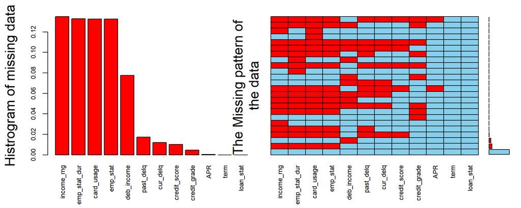

```
##
##  Variables sorted by number of missings:
##      Variable        Count
##    income_rng 0.1349523195
##  emp_stat_dur 0.1327557051
##    card_usage 0.1325639372
##      emp_stat 0.1325290703
##    deb_income 0.0776834435
##     past_delq 0.0172591133
##      cur_delq 0.0121511131
##  credit_score 0.0103031677
##  credit_grade 0.0047418978
##           APR 0.0004358362
##          term 0.0000000000
##     loan_stat 0.0000000000
```

### Plot Two

Prosper has her own credit scoring system, and the credit score generated has a positive correlation with the credit score from other agents. This suggests Prosper uses some information that is also available from other agents to calculate the credit score of the borrowers or Prosper uses those non-Prosper credit scores to support her own credit score calculation.

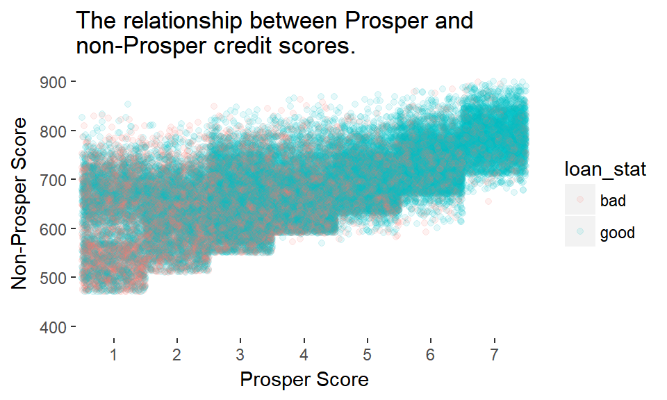

### Plot Three

The significant relationship between the APR and the Prosper credit score suggests Prosper consults her own credit system for calculating the APR of the borrowers. We can see there is more bad loan when the credit score is poor and the APR is high, and this may be due to the compound effect of higher rate (larger amount of month payment) and poorer credit score (borrower’s financial health).

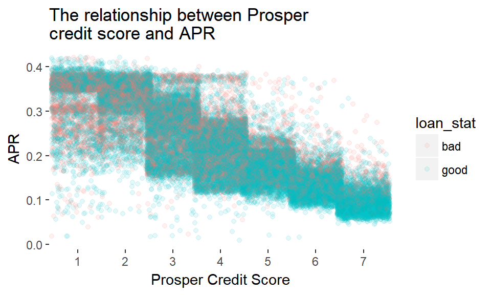

# Reflection

## About R

I general use Python for data analysis, therefore I need to get used to the R in order to perform the EDA in this notebook. I found that the syntax of R is not that difficult to get used to, and I spent more time on understand the data structures of R, for instance , factor. The concept of visualization tool, plotting, is very different from Python package like matplotlib. The learning curve is steep but it allows complex visualization with less preparation on the data. It is not good to reinvent the wheel, so it is good to choose the available packages for solving the problems. I realized that there are a lot of various packages available in R, but the challenge is to choose the most suitable one.

## About the data

The dataset is obtained from the Prosper (probably using Prosper API). Although definition of the variables is available, I still took quite amount of time to understand and decide the variable of interest for this EDA. The variables in the dataset are mixed types which increases the difficulty in exploratory analysis. A preliminary classification model is developed, and the results is not that promising. Further data cleaning and model development are required to achieve better results.

Also, there are 81 variables in the dataset and I only explore a subset of the data. More questions can be answered, for example, the borrower’s payment pattern, the chance of a borrower to past the due, the optimized interest rate, risk management etc. To fully utilize the dataset, however, a significant effort on data wrangling is required.